# A Time-Series Analysis on the Philippines' Inflation Rate from 1960 to 2021

## (With the terms' corresponding president)

Von Stephen Carandang Andre Mhiko Carandang Gianello Montenegro Mikaela Raymundo

BSECE - T4A

January 22, 2024

Submitted To: Engr. Aisa Mijeno-Labastilla, PCpE

**Major Assessment 3 / Capstone Assessment**

**Training and Evaluation of the Gathered Data**

**First Semester SY 2023-2024**

**I. Introduction / Problem Statement**

The challenge at hand revolves around comprehending the dynamic patterns of inflation rates in the Philippines and extracting pertinent information crucial for formulating solutions aimed at mitigating inflation or maintaining it at manageable levels. Inflation, denoting the rate at which the general price levels of goods and services increase, subsequently diminishing the purchasing power of a currency, is subject to continuous fluctuations influenced by diverse factors, including economic conditions, global dynamics, and various external influences.

The primary objective is to delve into the intricate relationship between inflation rates and presidential administrations. Across different presidential tenures, the impact on inflation is evident, shaped by varied factors such as monetary policy, fiscal policy, regulatory measures, trade policies, economic stability, confidence levels, and supply chain dynamics. Analyzing these components aids in identifying effective administration techniques conducive to good governance.

Moreover, an integral aspect of this analysis involves scrutinizing data pertaining to government debts. Recognizing the interconnectedness with fiscal policy—encompassing government spending—provides valuable insights, as such expenditures can exert considerable influence on inflation. This comprehensive understanding of inflation and its interconnected facets lays the groundwork for devising sound governance strategies.

Our target SDGs are SDG 16: Peace, Justice, and Strong Institutions. Understanding the impact of presidential administrations on inflation involves examining policies and governance, aligning with the goal of promoting peaceful and inclusive societies. Then, SDG 8 which is Decent Work and Economic Growth. Understanding inflation in the context of economic conditions, policies, and stability, aligning with the goal of promoting sustained, inclusive, and sustainable economic growth.

**II. Review of Related Literature**

*Data Engineering* Data Engineering is prominently used within this project. Ensuring that data is prepared for analysis and a proper data analysis pipeline is curated for a smooth analysis pipeline.

*Data Analysis* Data Analysis is the art of recognizing trends within data visualization. It is evident within the project's discussion that there is a proper and cohesive interpretation of data visualization.

Overall, the proponents delved into a rabbithole of multiple Data Science topics from Data Analysis up to Data Science itself; with Machine Learning and AI. The Data Science concepts are properly expressed within this project to ensure a cohesive interpretation is made through the gathered dataset.

**III. Gathered Data / Dataset**

- [Inflation Dataset](https://fred.stlouisfed.org/series/FPCPITOTLZGPHL)
- [Debt Dataset](https://statrealm.com/sector/economy/external-debt-stocks-total-dod-current-us/PHL)

**IV. Objectives**

**V. Conceptual**

[figure not shown]

**VI. Data and Results**

**Philippine Debt** National Debt of the Philippines is a value that has multiple contributing variables. From the visualization of data it can be deduced that there is a consistent rise in National Debt for the Philippines. Even with some years where National Debt is being scraped off, there is still a consistent rise to the total value.

**VII. Conclusion**

As recommendation for future analysis on similar topics, it is recommended that a reliable and detailed dataset is used. Due to the limitations of resources, a generalized version of the dataset is used to meet project's demands. With a proper dataset, an accurate prediction and analysis can be better made.

**VIII. Share your thoughts individually and overall feedback after completing this course.**

**Von Stephenn Carandang** - In the multifaceted landscape of Electrical and Computer Engineering (ECE) data, the interplay of machine learning, regression, AI, classification, Jupyter, and deep learning forms a nexus of technological advancement and complexity. Utilizing Jupyter, engineers can seamlessly integrate code, data visualization, and explanatory text, fostering a collaborative and iterative approach to data exploration and model development. For instance, in a Jupyter notebook, one might leverage Python code to preprocess raw ECE data, applying machine learning algorithms for predictive modeling, and using interactive visualizations to gain insights into complex patterns like what we have done in our CAPSTONE. The versatility of Jupyter not only expedites the development process but also enhances the transparency and reproducibility of analyses, making it an indispensable tool in navigating the intricacies of ECE data and advancing the field's future possibilities.

**Andre Mhiko Carandang** - Reflecting on my ECE Date course, I've gained valuable skills in correlational analysis, time-series analysis, and regression analysis. Correlational analysis enhanced my ability to understand and measure relationships between variables. Time-series analysis equipped me to identify trends and predict outcomes over time. Regression analysis, focusing on modeling and prediction, provided a versatile toolkit for addressing real-world problems. Overall, the course has transformed my approach to data interpretation, emphasizing the power of quantitative analysis in unraveling complexities.

**Gianello Montenegro** - Completing the Data Science and Artificial Intelligence course has been an incredibly enriching journey that has not only expanded my technical skills but also deepened my understanding of the profound impact these fields have on various industries. From mastering the intricacies of machine learning algorithms to delving into advanced statistical modeling, the course equipped me with a versatile toolkit essential for extracting meaningful insights from data. Practical projects, such as building predictive models and implementing natural language processing techniques, not only challenged me but also provided hands-on experience in solving real-world problems. Additionally, the ethical considerations discussed throughout the course highlighted the responsibility that comes with wielding such powerful tools. Overall, this experience has ignited my passion for leveraging data to drive informed decision-making and has positioned me at the forefront of the ever-evolving landscape of data science and AI.

**Mikaela Raymundo** - My journey with Python has been both exhilarating and enlightening. From the early stages of grappling with syntax to the more complex realms of problem-solving, this programming language has been a constant companion in my quest for understanding the world of coding. In this reflection paper, I will share my experiences, challenges, and the growth I've witnessed during my exploration of Python.When I first delved into Python, the simplicity of its syntax immediately stood out. The readability of the code made it accessible, even for someone like me, who was relatively new to programming. The indentation-based structure not only enforced clean code but also taught me the importance of consistency in programming practices. However, as with any learning journey, challenges were inevitable. I found myself struggling with concepts like object-oriented programming and data structures. Understanding the logic behind algorithms required a shift in my thinking, and debugging became a daily ritual. Yet, these challenges were the crucibles in which my understanding of Python was forged.

**IX. Program Codes (Jupyter notebook)**

# 1. Import Dataset

```python
# Import Libraries
import pandas as pd
import numpy as np
import matplotlib.pyplot as plt
import seaborn as sns
import os
import warnings
import sklearn
# Negate the warnings
warnings.filterwarnings('ignore')

%matplotlib inline
```

```python
# Import the dataset for inflation
df_inflation = pd.read_csv('Philippine_Inflation.csv')
df_inflation.info
```

```
<bound method DataFrame.info of           DATE  FPCPITOTLZGPHL
0   1960-01-01        4.154822
1   1961-01-01        1.595633
2   1962-01-01        5.796652
3   1963-01-01        5.625549
4   1964-01-01        8.183079
..         ...             ...
58  2018-01-01        5.309347
59  2019-01-01        2.392065
60  2020-01-01        2.393162
61  2021-01-01        3.927180
62  2022-01-01        5.821158

[63 rows x 2 columns]>
```

```python
# Import the dataset for debt
df_debt = pd.read_csv('Debt data\Philippines, External debt stocks, total (DOD, current US$).csv')
df_debt.info
```

```
<bound method DataFrame.info of     Date         Value
0   1960           NaN
1   1961           NaN
2   1962           NaN
3   1963           NaN
4   1964           NaN
..   ...           ...
59  2019  8.362534e+10
60  2020  9.849369e+10
61  2021  1.064280e+11
62  2022           NaN
63  2023           NaN

[64 rows x 2 columns]>
```

# 2. Clean Dataset for Null Values

```python
df_inflation.isnull().sum()
```

```
DATE              0
FPCPITOTLZGPHL    0
dtype: int64
```

```python
df_debt.isnull().sum()
```

```
Date      0
Value    12
dtype: int64
```

```python
df_debt = df_debt.fillna(0)
df_debt.head()
```

|  | Date | Value |
| --- | --- | --- |
| 0 | 1960 | 0.0 |
| 1 | 1961 | 0.0 |
| 2 | 1962 | 0.0 |
| 3 | 1963 | 0.0 |
| 4 | 1964 | 0.0 |

# 3. Combine both datasets

> (Compute necessary missing values for Debt)

```python
# Rename columns
df_debt.rename(columns={'Value' : 'Debt'}, inplace=True)
df_inflation.rename(columns={'DATE': 'Year', 'FPCPITOTLZGPHL': 'Inflation Rate'}, inplace=True)
```

```python
# Convert the year to datetime
df_inflation['Year'] = pd.to_datetime(df_inflation['Year']).dt.year
df_inflation.head()
```

|  | Year | Inflation Rate |
| --- | --- | --- |
| 0 | 1960 | 4.154822 |
| 1 | 1961 | 1.595633 |
| 2 | 1962 | 5.796652 |
| 3 | 1963 | 5.625549 |
| 4 | 1964 | 8.183079 |

```python
debt_total = df_debt['Debt'].tolist()

df_inflation['Total Debt'] = debt_total[:len(df_inflation)]
df_inflation.info()
df_inflation.head(70)
```

```
<class 'pandas.core.frame.DataFrame'>
RangeIndex: 63 entries, 0 to 62
Data columns (total 3 columns):
 #   Column          Non-Null Count  Dtype
---  ------          --------------  -----
 0   Year            63 non-null     int32
 1   Inflation Rate  63 non-null     float64
 2   Total Debt      63 non-null     float64
dtypes: float64(2), int32(1)
memory usage: 1.4 KB
```

|  | Year | Inflation Rate | Total Debt |
| --- | --- | --- | --- |
| 0 | 1960 | 4.154822 | 0.000000e+00 |
| 1 | 1961 | 1.595633 | 0.000000e+00 |
| 2 | 1962 | 5.796652 | 0.000000e+00 |
| 3 | 1963 | 5.625549 | 0.000000e+00 |
| 4 | 1964 | 8.183079 | 0.000000e+00 |
| ... | ... | ... | ... |
| 58 | 2018 | 5.309347 | 7.896729e+10 |
| 59 | 2019 | 2.392065 | 8.362534e+10 |
| 60 | 2020 | 2.393162 | 9.849369e+10 |
| 61 | 2021 | 3.927180 | 1.064280e+11 |
| 62 | 2022 | 5.821158 | 0.000000e+00 |

63 rows × 3 columns

```python
def format_currency(x):
    if x >= 1e9 or x <= -1e9:
        return x*1e-9
    elif x >= 1e6 or x <= -1e6:
        return x*1e-6
    elif x >= 1e3 or x <= -1e3:
        return x*1e-3
    else:
        return x


df_inflation['Total Debt'] = df_inflation['Total Debt'].apply(format_currency)
df_inflation.head(70)
```

|  | Year | Inflation Rate | Total Debt |
| --- | --- | --- | --- |
| 0 | 1960 | 4.154822 | 0.000000 |
| 1 | 1961 | 1.595633 | 0.000000 |
| 2 | 1962 | 5.796652 | 0.000000 |
| 3 | 1963 | 5.625549 | 0.000000 |
| 4 | 1964 | 8.183079 | 0.000000 |
| ... | ... | ... | ... |
| 58 | 2018 | 5.309347 | 78.967285 |
| 59 | 2019 | 2.392065 | 83.625344 |
| 60 | 2020 | 2.393162 | 98.493688 |
| 61 | 2021 | 3.927180 | 106.428000 |
| 62 | 2022 | 5.821158 | 0.000000 |

63 rows × 3 columns

```python
# Reset the index of df_inflation
df_inflation.reset_index(drop=True, inplace=True)

# Calculate added debt per year
added_debt_per_year = []
for i in range(1, len(df_inflation['Total Debt'])):
    added_debt_per_year.append(df_inflation['Total Debt'][i] - df_inflation['Total Debt'][i-1])

added_debt_per_year.pop()
added_debt_per_year.insert(0, 0.0)
print(len(added_debt_per_year))

df_inflation = df_inflation[:-1]
# # Add the 'Added Debt' column to df_inflation
df_inflation['Added Debt'] = added_debt_per_year
```

```
62
```

```python
pd.set_option('display.max_rows', None)
df_inflation.head(70)
```

|  | Year | Inflation Rate | Total Debt | Added Debt |
| --- | --- | --- | --- | --- |
| 0 | 1960 | 4.154822 | 0.000000 | 0.000000 |
| 1 | 1961 | 1.595633 | 0.000000 | 0.000000 |
| 2 | 1962 | 5.796652 | 0.000000 | 0.000000 |
| 3 | 1963 | 5.625549 | 0.000000 | 0.000000 |
| 4 | 1964 | 8.183079 | 0.000000 | 0.000000 |
| 5 | 1965 | 2.564103 | 0.000000 | 0.000000 |
| 6 | 1966 | 5.400000 | 0.000000 | 0.000000 |
| 7 | 1967 | 6.253953 | 0.000000 | 0.000000 |
| 8 | 1968 | 2.358806 | 0.000000 | 0.000000 |
| 9 | 1969 | 1.955510 | 0.000000 | 0.000000 |
| 10 | 1970 | 14.381462 | 2.196028 | 2.196028 |
| 11 | 1971 | 21.403344 | 2.419453 | 0.223425 |
| 12 | 1972 | 8.204034 | 2.671171 | 0.251719 |
| 13 | 1973 | 16.580032 | 2.761258 | 0.090087 |
| 14 | 1974 | 34.163592 | 3.305258 | 0.544000 |
| 15 | 1975 | 6.761403 | 4.170680 | 0.865422 |
| 16 | 1976 | 9.199227 | 6.039461 | 1.868781 |
| 17 | 1977 | 9.898752 | 8.183428 | 2.143967 |
| 18 | 1978 | 7.334526 | 10.772165 | 2.588737 |
| 19 | 1979 | 17.533333 | 13.281604 | 2.509439 |
| 20 | 1980 | 18.200510 | 17.417202 | 4.135599 |
| 21 | 1981 | 13.082599 | 20.785921 | 3.368719 |
| 22 | 1982 | 10.221727 | 24.412639 | 3.626718 |
| 23 | 1983 | 10.029357 | 24.211104 | -0.201535 |
| 24 | 1984 | 50.338976 | 24.356702 | 0.145598 |
| 25 | 1985 | 23.103107 | 26.637307 | 2.280605 |
| 26 | 1986 | 1.148138 | 28.204157 | 1.566850 |
| 27 | 1987 | 4.069767 | 29.784763 | 1.580606 |
| 28 | 1988 | 13.860069 | 28.932152 | -0.852611 |
| 29 | 1989 | 12.242991 | 28.652845 | -0.279307 |
| 30 | 1990 | 12.177352 | 30.579851 | 1.927006 |
| 31 | 1991 | 19.261459 | 32.493339 | 1.913488 |
| 32 | 1992 | 8.651004 | 33.219039 | 0.725700 |
| 33 | 1993 | 6.716311 | 36.142381 | 2.923342 |
| 34 | 1994 | 10.386473 | 40.253267 | 4.110886 |
| 35 | 1995 | 6.831996 | 39.374934 | -0.878333 |
| 36 | 1996 | 7.476104 | 43.997124 | 4.622190 |
| 37 | 1997 | 5.590259 | 50.702237 | 6.705112 |
| 38 | 1998 | 9.234934 | 53.593376 | 2.891140 |
| 39 | 1999 | 5.939049 | 58.470128 | 4.876751 |
| 40 | 2000 | 3.977125 | 58.445299 | -0.024829 |
| 41 | 2001 | 5.345502 | 58.391332 | -0.053967 |
| 42 | 2002 | 2.722772 | 60.054060 | 1.662728 |
| 43 | 2003 | 2.289157 | 62.754159 | 2.700098 |
| 44 | 2004 | 4.829211 | 61.142719 | -1.611440 |
| 45 | 2005 | 6.516854 | 58.687842 | -2.454877 |
| 46 | 2006 | 5.485232 | 57.591538 | -1.096303 |
| 47 | 2007 | 2.900000 | 59.170383 | 1.578845 |
| 48 | 2008 | 8.260447 | 58.261783 | -0.908600 |
| 49 | 2009 | 4.219031 | 55.976153 | -2.285630 |
| 50 | 2010 | 3.789836 | 65.349887 | 9.373733 |
| 51 | 2011 | 4.718417 | 66.105388 | 0.755501 |
| 52 | 2012 | 3.026964 | 69.363026 | 3.257638 |
| 53 | 2013 | 2.582688 | 66.191185 | -3.171841 |
| 54 | 2014 | 3.597823 | 77.168095 | 10.976910 |
| 55 | 2015 | 0.674193 | 76.269544 | -0.898551 |
| 56 | 2016 | 1.253699 | 74.750940 | -1.518604 |
| 57 | 2017 | 2.853188 | 73.105675 | -1.645265 |
| 58 | 2018 | 5.309347 | 78.967285 | 5.861610 |
| 59 | 2019 | 2.392065 | 83.625344 | 4.658058 |
| 60 | 2020 | 2.393162 | 98.493688 | 14.868344 |
| 61 | 2021 | 3.927180 | 106.428000 | 7.934312 |

```python
# dictionary of presidents and their years in office
pres_dict = {
    'C. Garcia': [1960],
    'D. Macapagal': list(range(1961, 1965)),
    'F. Marcos': list(range(1965, 1986)),
    'C. Aquino': list(range(1986, 1992)),
    'F. Ramos': list(range(1992, 1998)),
    'J. Estrada': list(range(1998, 2001)),
    'G. Arroyo': list(range(2001, 2010)),
    'B. Aquino': list(range(2010, 2016)),
    'R. Duterte': list(range(2016, 2022)),
}

def get_president(year):
    for president, years in pres_dict.items():
        if year in years:
            return president
    return None


df_inflation['President'] = df_inflation['Year'].apply(get_president)

df_inflation.head(65)
```

|  | Year | Inflation Rate | Total Debt | Added Debt | President |
| --- | --- | --- | --- | --- | --- |
| 0 | 1960 | 4.154822 | 0.000000 | 0.000000 | C. Garcia |
| 1 | 1961 | 1.595633 | 0.000000 | 0.000000 | D. Macapagal |
| 2 | 1962 | 5.796652 | 0.000000 | 0.000000 | D. Macapagal |
| 3 | 1963 | 5.625549 | 0.000000 | 0.000000 | D. Macapagal |
| 4 | 1964 | 8.183079 | 0.000000 | 0.000000 | D. Macapagal |
| 5 | 1965 | 2.564103 | 0.000000 | 0.000000 | F. Marcos |
| 6 | 1966 | 5.400000 | 0.000000 | 0.000000 | F. Marcos |
| 7 | 1967 | 6.253953 | 0.000000 | 0.000000 | F. Marcos |
| 8 | 1968 | 2.358806 | 0.000000 | 0.000000 | F. Marcos |
| 9 | 1969 | 1.955510 | 0.000000 | 0.000000 | F. Marcos |
| 10 | 1970 | 14.381462 | 2.196028 | 2.196028 | F. Marcos |
| 11 | 1971 | 21.403344 | 2.419453 | 0.223425 | F. Marcos |
| 12 | 1972 | 8.204034 | 2.671171 | 0.251719 | F. Marcos |
| 13 | 1973 | 16.580032 | 2.761258 | 0.090087 | F. Marcos |
| 14 | 1974 | 34.163592 | 3.305258 | 0.544000 | F. Marcos |
| 15 | 1975 | 6.761403 | 4.170680 | 0.865422 | F. Marcos |
| 16 | 1976 | 9.199227 | 6.039461 | 1.868781 | F. Marcos |
| 17 | 1977 | 9.898752 | 8.183428 | 2.143967 | F. Marcos |
| 18 | 1978 | 7.334526 | 10.772165 | 2.588737 | F. Marcos |
| 19 | 1979 | 17.533333 | 13.281604 | 2.509439 | F. Marcos |
| 20 | 1980 | 18.200510 | 17.417202 | 4.135599 | F. Marcos |
| 21 | 1981 | 13.082599 | 20.785921 | 3.368719 | F. Marcos |
| 22 | 1982 | 10.221727 | 24.412639 | 3.626718 | F. Marcos |
| 23 | 1983 | 10.029357 | 24.211104 | -0.201535 | F. Marcos |
| 24 | 1984 | 50.338976 | 24.356702 | 0.145598 | F. Marcos |
| 25 | 1985 | 23.103107 | 26.637307 | 2.280605 | F. Marcos |
| 26 | 1986 | 1.148138 | 28.204157 | 1.566850 | C. Aquino |
| 27 | 1987 | 4.069767 | 29.784763 | 1.580606 | C. Aquino |
| 28 | 1988 | 13.860069 | 28.932152 | -0.852611 | C. Aquino |
| 29 | 1989 | 12.242991 | 28.652845 | -0.279307 | C. Aquino |
| 30 | 1990 | 12.177352 | 30.579851 | 1.927006 | C. Aquino |
| 31 | 1991 | 19.261459 | 32.493339 | 1.913488 | C. Aquino |
| 32 | 1992 | 8.651004 | 33.219039 | 0.725700 | F. Ramos |
| 33 | 1993 | 6.716311 | 36.142381 | 2.923342 | F. Ramos |
| 34 | 1994 | 10.386473 | 40.253267 | 4.110886 | F. Ramos |
| 35 | 1995 | 6.831996 | 39.374934 | -0.878333 | F. Ramos |
| 36 | 1996 | 7.476104 | 43.997124 | 4.622190 | F. Ramos |
| 37 | 1997 | 5.590259 | 50.702237 | 6.705112 | F. Ramos |
| 38 | 1998 | 9.234934 | 53.593376 | 2.891140 | J. Estrada |
| 39 | 1999 | 5.939049 | 58.470128 | 4.876751 | J. Estrada |
| 40 | 2000 | 3.977125 | 58.445299 | -0.024829 | J. Estrada |
| 41 | 2001 | 5.345502 | 58.391332 | -0.053967 | G. Arroyo |
| 42 | 2002 | 2.722772 | 60.054060 | 1.662728 | G. Arroyo |
| 43 | 2003 | 2.289157 | 62.754159 | 2.700098 | G. Arroyo |
| 44 | 2004 | 4.829211 | 61.142719 | -1.611440 | G. Arroyo |
| 45 | 2005 | 6.516854 | 58.687842 | -2.454877 | G. Arroyo |
| 46 | 2006 | 5.485232 | 57.591538 | -1.096303 | G. Arroyo |
| 47 | 2007 | 2.900000 | 59.170383 | 1.578845 | G. Arroyo |
| 48 | 2008 | 8.260447 | 58.261783 | -0.908600 | G. Arroyo |
| 49 | 2009 | 4.219031 | 55.976153 | -2.285630 | G. Arroyo |
| 50 | 2010 | 3.789836 | 65.349887 | 9.373733 | B. Aquino |
| 51 | 2011 | 4.718417 | 66.105388 | 0.755501 | B. Aquino |
| 52 | 2012 | 3.026964 | 69.363026 | 3.257638 | B. Aquino |
| 53 | 2013 | 2.582688 | 66.191185 | -3.171841 | B. Aquino |
| 54 | 2014 | 3.597823 | 77.168095 | 10.976910 | B. Aquino |
| 55 | 2015 | 0.674193 | 76.269544 | -0.898551 | B. Aquino |
| 56 | 2016 | 1.253699 | 74.750940 | -1.518604 | R. Duterte |
| 57 | 2017 | 2.853188 | 73.105675 | -1.645265 | R. Duterte |
| 58 | 2018 | 5.309347 | 78.967285 | 5.861610 | R. Duterte |
| 59 | 2019 | 2.392065 | 83.625344 | 4.658058 | R. Duterte |
| 60 | 2020 | 2.393162 | 98.493688 | 14.868344 | R. Duterte |
| 61 | 2021 | 3.927180 | 106.428000 | 7.934312 | R. Duterte |

# 4. Values Visualization

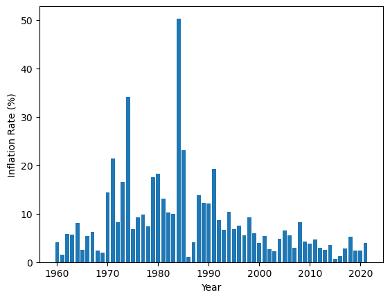

```python
plt.bar(df_inflation['Year'], df_inflation['Inflation Rate'])
plt.xlabel('Year')
plt.ylabel('Inflation Rate (%)')
```

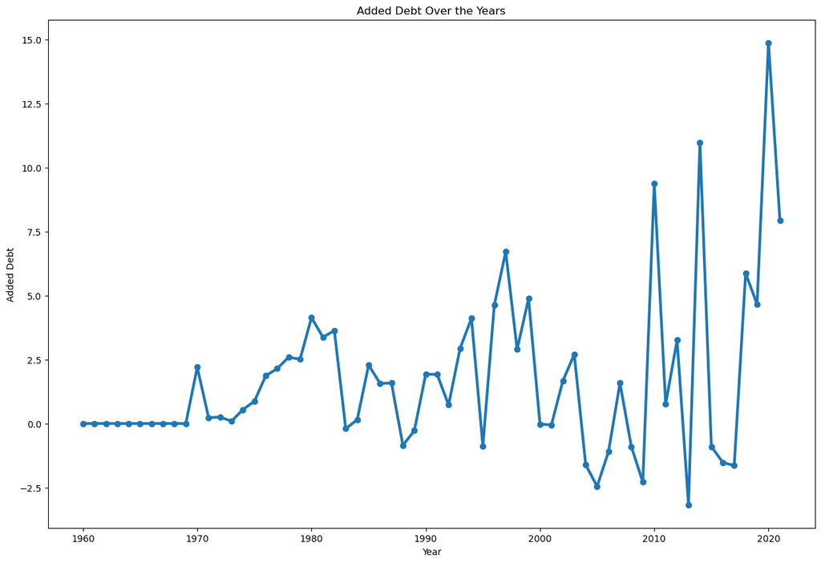

```python
# Line plot
plt.figure(figsize=(15, 10))
plt.plot(df_inflation['Year'], df_inflation['Added Debt'], linewidth=3)
plt.scatter(df_inflation['Year'], df_inflation['Added Debt'])
plt.xlabel('Year')
plt.ylabel('Added Debt')
plt.title('Added Debt Over the Years')

plt.show()
```

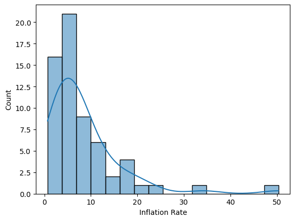

```python
sns.histplot(df_inflation['Inflation Rate'], kde=True)
```

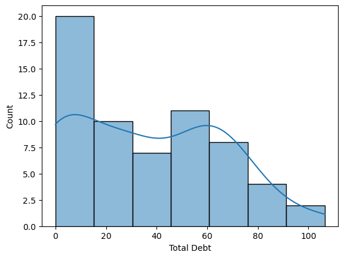

```python
sns.histplot(df_inflation['Total Debt'], kde=True)
```

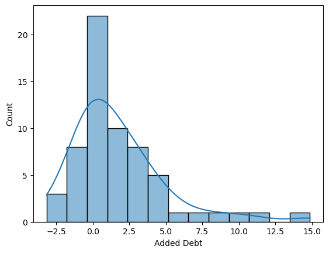

```python
sns.histplot(df_inflation['Added Debt'], kde=True)
```

# 5. Data interpretation per president term

## 5.A Inflation Rate Per Presidential Term

> (n.b., some values from the dataset are not enough for completely capturing the inflation rate for some presidential terms)

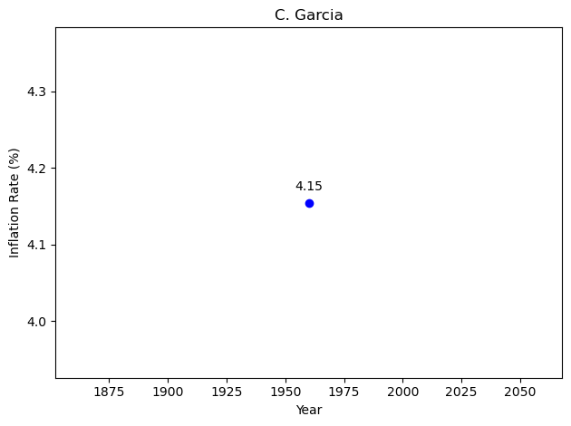

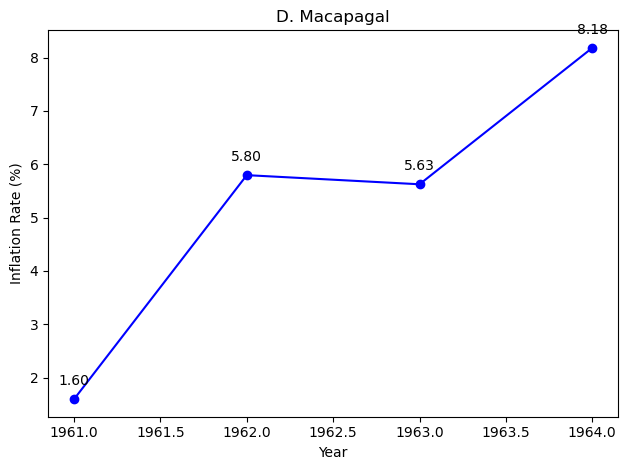

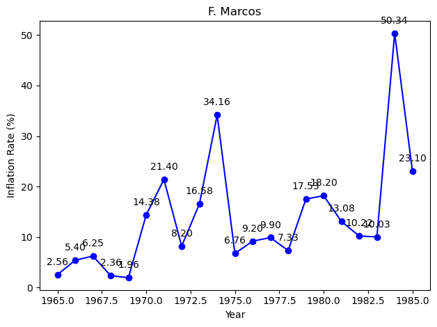

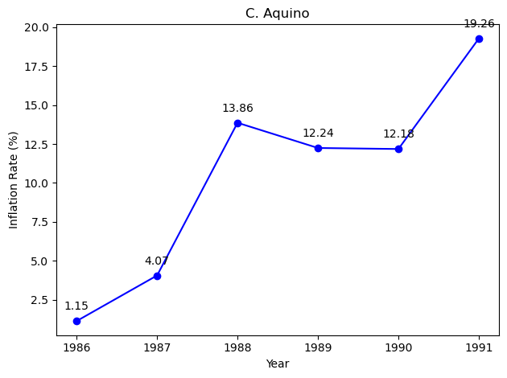

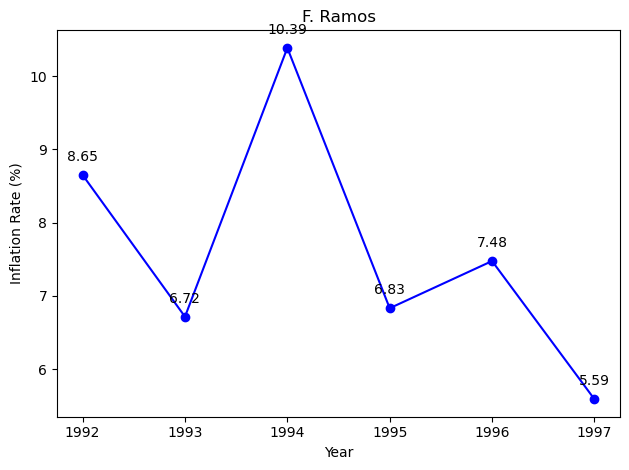

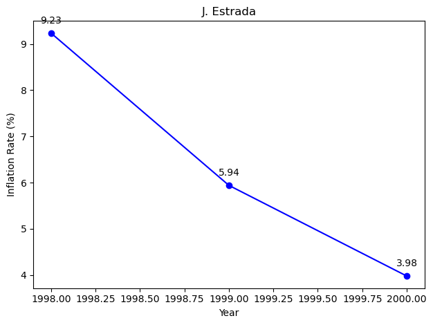

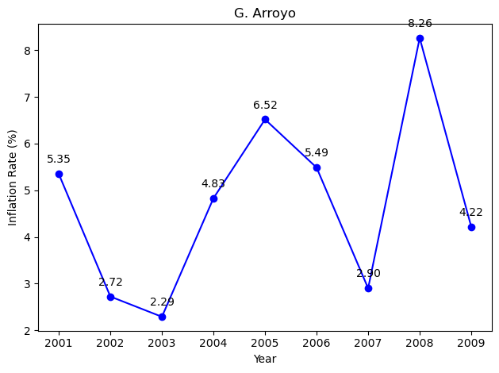

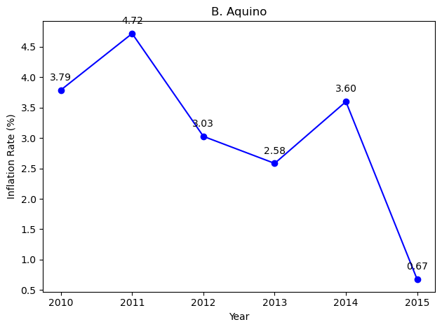

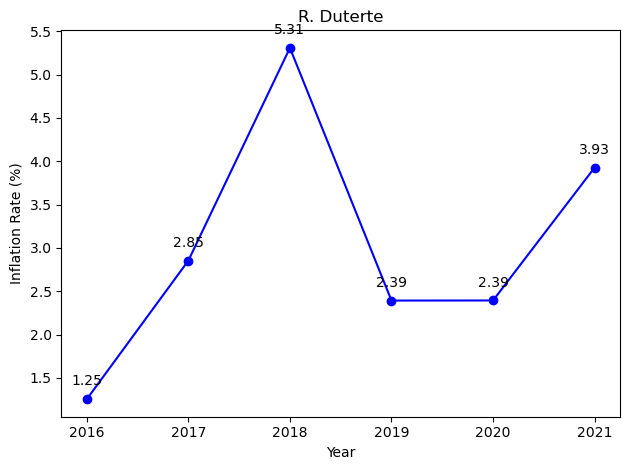

```python
for pres in pres_dict:
    plt.title(pres)
    plt.scatter(df_inflation[df_inflation['President'] == pres]['Year'], df_inflation[df_inflation['President'] == pres]['Inflation Rate'], color='blue')
    plt.xlabel('Year')
    plt.ylabel('Inflation Rate (%)')
    plt.plot(df_inflation[df_inflation['President'] == pres]['Year'], df_inflation[df_inflation['President'] == pres]['Inflation Rate'], color='blue')
    plt.tight_layout()

    # Add value annotation to each datapoint
    for x, y in zip(df_inflation[df_inflation['President'] == pres]['Year'], df_inflation[df_inflation['President'] == pres]['Inflation Rate']):
        plt.annotate(f'{y:.2f}', (x, y), textcoords="offset points", xytext=(0,10), ha='center')

    plt.show()
```

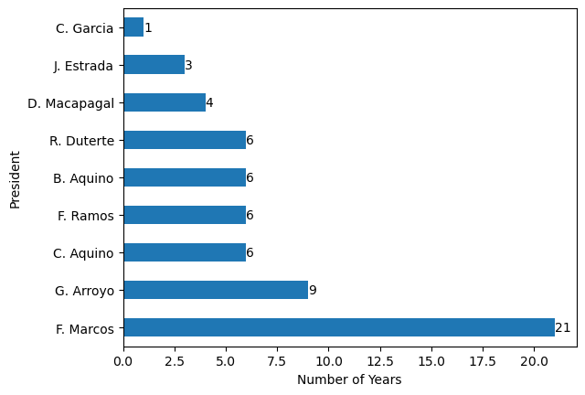

```python
df_inflation['President'].value_counts().plot(kind='barh')
plt.xlabel('Number of Years')
plt.ylabel('President')


# Add values to each bar
for i, value in enumerate(df_inflation['President'].value_counts()):
    plt.text(value, i, str(round(value, 2)), ha='left', va='center')
```

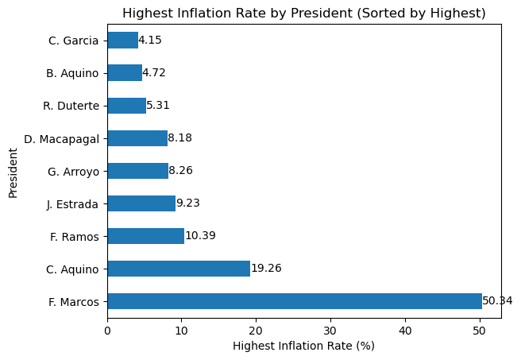

```python
highest_inflation = df_inflation.groupby('President')['Inflation Rate'].max().sort_values(ascending=False)
highest_inflation.plot(kind='barh')
highest_inflation.head()

plt.title('Highest Inflation Rate by President (Sorted by Highest)')
plt.xlabel('Highest Inflation Rate (%)')
plt.ylabel('President')

# Add values to each bar
for i, value in enumerate(highest_inflation):
    plt.text(value, i, str(round(value, 2)), ha='left', va='center')

plt.show()
```

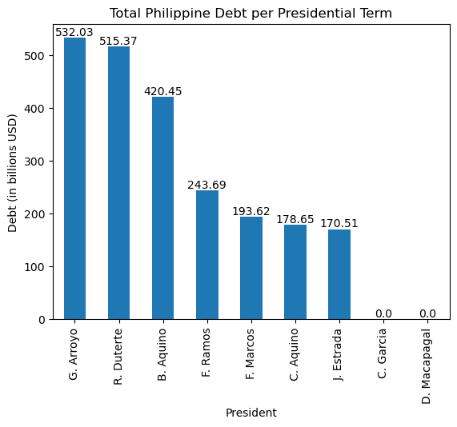

```python
debt_per_president = df_inflation.groupby('President')['Total Debt'].sum().sort_values(ascending=False)
debt_per_president.plot(kind='bar')

plt.title('Total Philippine Debt per Presidential Term')
plt.xlabel('President')
plt.ylabel('Debt (in billions USD)')

# Add values to each bar
for i, value in enumerate(debt_per_president):
    plt.text(i, value, str(round(value, 2)), ha='center', va='bottom')

plt.show()
```

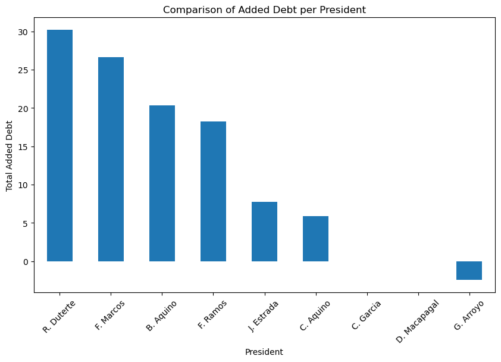

```python
# Group by 'President' and calculate the sum of 'Added Debt'
debt_by_president = df_inflation.groupby('President')['Added Debt'].sum().sort_values(ascending=False)

# Plot the results for all presidents
debt_by_president.plot(kind='bar', figsize=(10, 6))
plt.ylabel('Total Added Debt')
plt.title('Comparison of Added Debt per President')
plt.xticks(rotation=45)  # Rotate x-axis labels for better readability
plt.show()
```

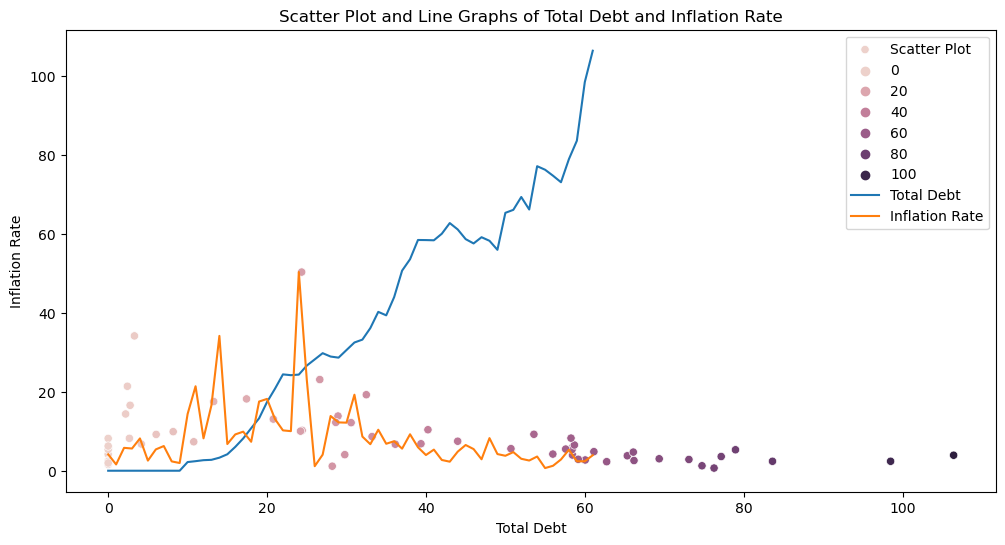

```python
column1 = 'Total Debt'
column2 = 'Inflation Rate'

# Create a scatter plot with different colors for each column
plt.figure(figsize=(12, 6))

sns.scatterplot(x=column1, y=column2, data=df_inflation, hue=df_inflation[column1], label='Scatter Plot')

# Line graph for column1
sns.lineplot(x=df_inflation.index, y=df_inflation[column1], label=column1)

# Line graph for column2
sns.lineplot(x=df_inflation.index, y=df_inflation[column2], label=column2)

# Set plot labels and title
plt.xlabel(column1)
plt.ylabel(column2)
plt.title(f'Scatter Plot and Line Graphs of {column1} and {column2}')

# Show the legend
plt.legend()

# Show the plot
plt.show()
```

# 6. Prediction of Inflation Rate

We'll be using Random Forest for our Machine Learning Model. Compared to Decision Trees, Random Forest has a more robust structure to identify underlying patterns.

## Import Machine Learning Libraries

```python
from sklearn.model_selection import train_test_split
from sklearn.ensemble import RandomForestRegressor
from sklearn.metrics import mean_squared_error, r2_score
```

```python
feature_cols = ['Total Debt', 'Added Debt']
X = df_inflation[feature_cols]
y = df_inflation['Inflation Rate']

# Split the data into training and testing sets
X_train, X_test, y_train, y_test = train_test_split(X, y, test_size=0.1, random_state=42)

# Create the model and train it
forest_model = RandomForestRegressor()
forest_model.fit(X_train, y_train)

# Make predictions
y_pred = forest_model.predict(X_test)

# Calculate the mean squared error and the coefficient of determination (r2 score)
mse = mean_squared_error(y_test, y_pred)
r2 = r2_score(y_test, y_pred)

# Print the results
print(f'Mean squared error: {mse:.2f}')
print(f'Coefficient of determination: {r2:.2f}')
print(f'Root mean squared error: {np.sqrt(mse):.2f}')
```

```
Mean squared error: 3.27
Coefficient of determination: 0.57
Root mean squared error: 1.81
```

## Comparison of Original Data and Model Training Results

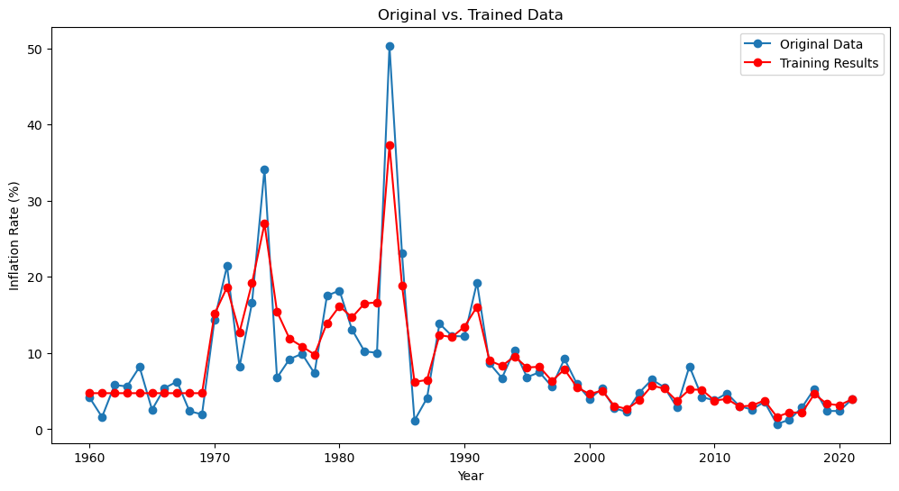

```python
# Plot the original data
plt.figure(figsize=(12, 6))  # Increase the figure size
plt.plot(df_inflation['Year'], df_inflation['Inflation Rate'], label='Original Data', marker='o')

# Plot the predicted data
plt.plot(df_inflation['Year'], forest_model.predict(X), label='Training Results', marker='o', color='red')

# Set labels and title
plt.xlabel('Year')
plt.ylabel('Inflation Rate (%)')
plt.title('Original vs. Trained Data')

# Add a legend
plt.legend()

# Show the plot
plt.show()
```

```python
# Find Average increase of Total Debt Per Year
avg_increase = df_inflation['Total Debt'].diff().mean()
print(f'Average increase of Total Debt Per Year: {avg_increase:.2f}')
```

```
Average increase of Total Debt Per Year: 1.74
```

## Inflation Rate Predictions with RandomForest

```python
# Create future years
future_years = np.arange(2021, 2028)

# Create a dataframe with the future years
df_future = pd.DataFrame({'Year': future_years})

# Set initial values
initial_total_debt = df_inflation['Total Debt'].tolist()[-1]
df_future['Total Debt'] = initial_total_debt
df_future['Added Debt'] = avg_increase

# Simulate Total Debt increase for each year
for year in range(1, len(future_years)):
    # Calculate Total Debt for the current year based on the average increase
    total_debt = df_future['Total Debt'].iloc[year - 1] + avg_increase

    # Update 'Total Debt' column
    df_future.at[year, 'Total Debt'] = total_debt

# Make predictions for the future years
df_future['Inflation Rate'] = forest_model.predict(X_test)

# Show the dataframe
print(df_future)
```

```
   Year  Total Debt  Added Debt  Inflation Rate
0  2021  106.428000    1.744721        3.761219
1  2022  108.172721    1.744721        2.214829
2  2023  109.917443    1.744721        4.732531
3  2024  111.662164    1.744721        2.163338
4  2025  113.406885    1.744721        4.732531
5  2026  115.151607    1.744721        5.215562
6  2027  116.896328    1.744721       11.881289
```

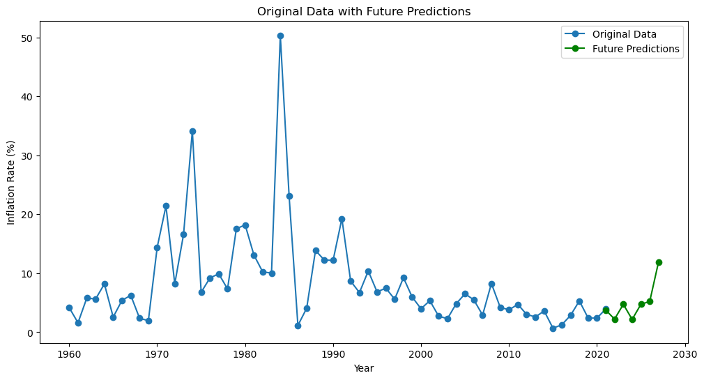

```python
# Plot the original data
plt.figure(figsize=(12, 6))  # Increase the figure size
plt.plot(df_inflation['Year'], df_inflation['Inflation Rate'], label='Original Data', marker='o')

# Plot the future predictions
plt.plot(df_future['Year'], df_future['Inflation Rate'], label='Future Predictions', marker='o', color='green')

# Set labels and title
plt.xlabel('Year')
plt.ylabel('Inflation Rate (%)')
plt.title('Original Data with Future Predictions')

# Add a legend
plt.legend()

# Show the plot
plt.show()
```

[figure not shown]

```python
# Filter the original data for years 2018-2020
original_data_subset = df_inflation[(df_inflation['Year'] >= 2015) & (df_inflation['Year'] <= 2020)]

# Plot the original data
plt.figure(figsize=(12, 6))  # Increase the figure size
plt.plot(original_data_subset['Year'], original_data_subset['Inflation Rate'], label='Original Data', marker='o')

# Plot the future predictions
plt.plot(df_future['Year'], df_future['Inflation Rate'], label='Future Predictions', marker='o', color='green')

# Connect the last data point of the original dataset and the first point of the predicted dataset with a line
last_original_year = original_data_subset['Year'].iloc[-1]
first_predicted_year = df_future['Year'].iloc[0]
last_original_inflation = original_data_subset['Inflation Rate'].iloc[-1]
first_predicted_inflation = df_future['Inflation Rate'].iloc[0]
plt.plot([last_original_year, first_predicted_year], [last_original_inflation, first_predicted_inflation], color='red')

# Add data values for each plot
for x, y in zip(original_data_subset['Year'], original_data_subset['Inflation Rate']):
    plt.annotate(f'{y:.2f}%', (x, y), textcoords="offset points", xytext=(0,10), ha='center')
for x, y in zip(df_future['Year'], df_future['Inflation Rate']):
    plt.annotate(f'{y:.2f}%', (x, y), textcoords="offset points", xytext=(0,10), ha='center')
plt.annotate(f'{last_original_inflation:.2f}%', (last_original_year, last_original_inflation), textcoords="offset points", xytext=(0,10), ha='center')
plt.annotate(f'{first_predicted_inflation:.2f}%', (first_predicted_year, first_predicted_inflation), textcoords="offset points", xytext=(0,10), ha='center')

# Set labels and title
plt.xlabel('Year')
plt.ylabel('Inflation Rate (%)')
plt.title('Original with Future Predictions (2018-2027)')

# Add a legend
plt.legend()

# Show the plot
plt.show()
```